# POF 2017 / 2018

João Pedro Simões Magro

01/09/2020

# Tratamento dos dados

Neste tópico serão descritos quais tratamentos de dados foram efetuados nos bancos de dados disponibilizados pelo IBGE da POF 2017/2018. Estas compreendem a seleção de de variáveis, observações de interesse, a criação de novas variáveis e também a mudança dos nomes de variáveis para facilitar sua manipulação. Os bancos de dados de interesse para a análise aqui descrita são aqueles que computam as características como renda, região, unidade federativa de cada domicílio consultado da pesquisa bem como os que trazem consigo observações das aquisições de produtos alimentícios. Estes são os arquivos *“MORADOR.rds”*, *“CADERNETA_COLETIVA.rds”* e *“DESPESA_INDIVIDUAL.rds”*.

#### Bibliotecas utilizadas

*Tidyverse, Data.table, Formattable e Janitor*

## Tratamento dos dados do arquivo *“MORADOR.rds”*

O primeiro tratamento de dados feito foi tabular as informações contidas no arquivo “moradores.rds” como um dataframe (df.) do tipo *“tibble”* **[1]**, isso pois toda manipulação dos dados será feita através da biblioteca “tidyverse”. No passo **[2]**, são selecionádas variáveis de interesse para a análise como unidade da federação, código da unidade primária de amostragem, entre outros. Logo em seguida é feita a alteração dos nomes das variáveis para facilitar o entendimento no momento de análise de variáveis **[3]**.

```r
#[1]
morador<-as_tibble(readRDS("MORADOR.rds"))

#[2]
MORADOR_UC_1<-morador%>%
  distinct(UF,ESTRATO_POF,TIPO_SITUACAO_REG,COD_UPA,NUM_DOM,NUM_UC,
           PESO_FINAL,.keep_all =TRUE)

MORADOR_UC<-MORADOR_UC_1[,c("UF","ESTRATO_POF","TIPO_SITUACAO_REG","COD_UPA","NUM_DOM","NUM_UC","COD_INFORMANTE","V0306","V0403","V0404","V0405","V0425","ANOS_ESTUDO","PESO","PESO_FINAL","RENDA_TOTAL")]


#[3]
colnames(MORADOR_UC)<-c("UF","ESTRATO_POF","TIPO_SITUACAO_REG","COD_UPA","NUM_DOM","NUM_UC","COD_INFORMANTE","SUBORDINAÇÃO","IDADE","SEXO","COR_RACA","CURSO_MAX","ANOS_ESTUDO","PESO","PESO_FINAL","RENDA_TOTAL")
```

### Criação de variáveis *nível* no df. *“MORADOR_UC”*

Feitas as alterações no banco de dados, o próximo passo foi a criação de variáveis *“nivel”* como idade, sexo, região (Urbana ou Rural) **[4]**. Este processo visa facilitar a filtragem de dados durante a eleboração de tabelas. Após criadas as variáveis foram indexadas ao *tibble* *“MORADOR_UC”* **[5]**.

```r
#[4]
UF_NIVEIS<-as_tibble(factor(findInterval(MORADOR_UC$UF,
                                         c(11,12,13,14,15,16,17,21,22,23,24
                                           ,25,26,27,28,29,31,32,33,35,41,
                                           42,43,50,51,52,53)),levels = 1:27,
                            labels = c("Rondônia","Acre","Amazonas","Roraima"
                                       ,"Pará","Amapá","Tocantins","Maranhão"
                                       ,"Piauí","Ceará","Rio Grande do Norte"
                                       ,"Paraíba","Pernambuco","Alagoas","Sergipe"
                                       ,"Bahia","Minas Gerais","Espírito Santo"
                                       ,"Rio de Janeiro","São Paulo","Paraná"
                                       ,"Santa Catarina","Rio Grande do Sul",
                                       "Mato Grosso do Sul","Mato Grosso","Goiás"
                                       ,"Distrito Federal")))
colnames(UF_NIVEIS)<-c("NIVEIS_UF")


#[4]
REG_NIVEIS<-as_tibble(factor(findInterval(MORADOR_UC$TIPO_SITUACAO_REG,
                                          c(1,2)),levels = 1:2,
                             labels = c("Urbano","Rural")))
colnames(REG_NIVEIS)<-c("NIVEIS_REG")


#[4]
REG_UF_NIVEIS<-as_tibble(factor(findInterval(MORADOR_UC$UF,
                                             c(11,29,35,43,53)),levels = 1:5,
                                labels = c("Norte","Nordeste","Sudeste","Sul"
                                           ,"Centro-oeste")))
colnames(REG_UF_NIVEIS)<-c("NIVEIS_REG_UF")


#[4]
IDADE_NIVEIS<-as_tibble(factor(1+findInterval(MORADOR_UC$IDADE,
                                              c(10,15,20,25,30,35,40,45,50,55,60
                                                ,65,70,75,Inf)),levels = 1:15,
                               labels = c("Até 10 anos",
                                          "Mais de 10 a 15",
                                          "Mais de 15 a 20",
                                          "Mais de 20 a 25",
                                          "Mais de 25 a 30",
                                          "Mais de 30 a 35",
                                          "Mais de 35 a 40",
                                          "Mais de 40 a 45",
                                          "Mais de 45 a 50",
                                          "Mais de 50 a 55",
                                          "Mais de 55 a 60",
                                          "Mais de 60 a 65",
                                          "Mais de 65 a 70",
                                          "Mais de 70 a 75",
                                          "Mais de 75"
                               )))
colnames(IDADE_NIVEIS)<-c("NIVEIS_IDADE")


#[4]
SEXO_NIVEIS<-as_tibble(factor(findInterval(MORADOR_UC$SEXO,
                                           c(1,2)),levels = 1:2,
                              labels = c("Homem","Mulher")))
colnames(SEXO_NIVEIS)<-c("NIVEIS_SEXO")


#[4]
CR_NIVEIS<-as_tibble(factor(findInterval(MORADOR_UC$COR_RACA,
                                         c(1,2,3,4,5,9)),levels = 1:6,
                            labels = c("Branca","Preta","Amarela","Parda",
                                       "Indígena","Sem declaração")))
colnames(CR_NIVEIS)<-c("NIVEIS_CR")


#[4]
EDU_NIVEIS<-as_tibble(factor(findInterval(MORADOR_UC$CURSO_MAX,
                                          c(1,2,3,4,5,6,7,8,9,10,11,12,13,14,15)),levels = 1:15,
                             labels = c("Creche","Pré-Escola",
                                        "Classe de alfabetização","Alfabetização de jovens e adultos",
                                        "Antigo primário","Antigo ginasial",
                                        "Primeiro grau","EJA - Primeiro grau",
                                        "Antigo ciêntífico","Segundo grau",
                                        "EJA - Segundo grau","Superior",
                                        "Especialização","Mestrado","Doutorado"
                             )))

colnames(EDU_NIVEIS)<-c("NIVEIS_EDU")


#[4]
RENDA_NIVEIS<-as_tibble(factor(1+findInterval(MORADOR_UC$RENDA_TOTAL,
                                              c(954,1908,2862,5724,9540,14310,
                                                23850,Inf)),levels = 1:8,
                               labels = c("Até 1","Mais de 1 a 2","Mais de 2 a 3",
                                          "Mais de 3 a 6","Mais de 6 a 10",
                                          "Mais de 10 a 15","Mais de 15 a 25",
                                          "Mais de 25")))
colnames(RENDA_NIVEIS)<-c("NIVEIS_RENDA")


#[5]
MORADOR_UC<-MORADOR_UC%>%
  mutate(NIVEIS_UF=UF_NIVEIS$NIVEIS_UF
         ,NIVEIS_REG_UF=REG_UF_NIVEIS$NIVEIS_REG_UF
         ,NIVEIS_REG=REG_NIVEIS$NIVEIS_REG
         ,NIVEIS_IDADE=IDADE_NIVEIS$NIVEIS_IDADE
         ,NIVEIS_SEXO=SEXO_NIVEIS$NIVEIS_SEXO
         ,NIVEIS_CR=CR_NIVEIS$NIVEIS_CR
         ,NIVEIS_EDU=EDU_NIVEIS$NIVEIS_EDU
         ,NIVEIS_RENDA=RENDA_NIVEIS$NIVEIS_RENDA)
```

## Tratamento dos dados dos arquivos *“CADERNETA_COLETIVA.rds”* e *“DESPESA_INDIVIDUAL.rds”*

Nestes dois arquivos estão contidos todas as variáveis correlatas ao consumo de alimentos, junto destas variáveis de produtos outras variáveis indesejadas também foram registradas fazendo com que seja necessário selecionar os dados de interesse para a análise. No primeiro passo os arquivos .rds são lidos e salvos mais uma vez como tibble **[1]**, em seguida os dados de interesse são copiados para um novo objeto tibble através de comandos lógicos que estipulam os intervalos e registros de interesse **[2]**. Ainda no passo **[2]**, duas novas variáveis são criadas, a variável *“codigo”* que será usada com a tabela de tradução de variáveis disponibilizada pelo IBGE, e a variável *“valor_mensal”* que é o cálculo (levando em conta o peso final da amostra) do valor mensal despendido com o produto. Após a seleção e criação de variáveis de interesse os cabeçalhos mais uma vez foram alterados para faciliar o entendimento durante a manipulação dos dados **[3]**.

```r
#[1]
caderneta_coletiva <- as_tibble(readRDS("CADERNETA_COLETIVA.rds"))
despesa_individual<- as_tibble(readRDS("DESPESA_INDIVIDUAL.rds"))

#[2]
CAD_COL<-caderneta_coletiva%>%
  mutate(codigo = round(V9001/100))%>%
  subset(codigo < 86001 | codigo > 89999)%>%
  mutate(valor_mensal=(V8000_DEFLA*FATOR_ANUALIZACAO*PESO_FINAL)/12)

DESP_IND<-despesa_individual%>%
  mutate(codigo = round(V9001/100))%>%
  subset(QUADRO==24|codigo==41001|codigo==48018|codigo==49075|codigo==49089)%>%
  mutate(valor_mensal = ifelse( QUADRO==24|QUADRO==41,
                                (V8000_DEFLA*FATOR_ANUALIZACAO*PESO_FINAL)/12,
                                (V8000_DEFLA*V9011*FATOR_ANUALIZACAO*PESO_FINAL)/12
  ))

#[3]
colnames(CAD_COL)<-c("UF","ESTRATO_POF","TIPO_SITUACAO_REG","COD_UPA"
                     ,"NUM_DOM","NUM_UC","QUADRO","SEQ","TIPO_AQUISICAO"
                     ,"FORMA_AQUISIÇÃO","VALOR_R$","DEFLATOR","V8000_DEFLA"
                     ,"COD_IMPUT_VALOR","FATOR_ANUALIZACAO","PESO"
                     ,"PESO_FINAL","RENDA_TOTAL","QTD_ADQ","UND_1","UND_2"
                     ,"QTD_FINAL","codigo","valor_mensal")

colnames(DESP_IND)<-c("UF","ESTRATO_POF","TIPO_SITUACAO_REG","COD_UPA"
                     ,"NUM_DOM","NUM_UC","COD_INFORMANTE","QUADRO","SEQ"
                     ,"TIPO_AQUISICAO","FORMA_AQUISIÇÃO","VALOR_R$"
                     ,"ULTIMA_COMPRA_MÊS","N_MESES_COMPRA","ESTADO_PROD"
                     ,"MOTIVO_VIAGEM","ORIGEM_VIAGEM","DEFLATOR","V8000_DEFLA"
                     ,"COD_IMPUT_VALOR","FATOR_ANUALIZACAO","PESO"
                     ,"PESO_FINAL","RENDA_TOTAL","codigo","valor_mensal")
```

### Criação de variáveis *nível* no df. *“CAD_COL”* e *“DESP_IND”*

Como no objeto *“MORADOR_UC”*, variáveis *nível* foram criadas e indexadas para os dois df. *“CAD_COL”* e *“DESP_IND”* **[4]** **[5]**.

```r
#[4] "CAD_COL"
UF_NIVEIS_CAD_COL<-as_tibble(factor(findInterval(CAD_COL$UF,
                                         c(11,12,13,14,15,16,17,21,22,23,24
                                           ,25,26,27,28,29,31,32,33,35,41,
                                           42,43,50,51,52,53)),levels = 1:27,
                            labels = c("Rondônia","Acre","Amazonas","Roraima"
                                       ,"Pará","Amapá","Tocantins","Maranhão"
                                       ,"Piauí","Ceará","Rio Grande do Norte"
                                       ,"Paraíba","Pernambuco","Alagoas","Sergipe"
                                       ,"Bahia","Minas Gerais","Espírito Santo"
                                       ,"Rio de Janeiro","São Paulo","Paraná"
                                       ,"Santa Catarina","Rio Grande do Sul",
                                       "Mato Grosso do Sul","Mato Grosso","Goiás"
                                       ,"Distrito Federal")))
colnames(UF_NIVEIS_CAD_COL)<-c("NIVEIS_UF")


#[4] "CAD_COL"
REG_NIVEIS_CAD_COL<-as_tibble(factor(findInterval(CAD_COL$TIPO_SITUACAO_REG,
                                          c(1,2)),levels = 1:2,
                             labels = c("Urbano","Rural")))
colnames(REG_NIVEIS_CAD_COL)<-c("NIVEIS_REG")


#[4] "CAD_COL"
REG_UF_NIVEIS_CAD_COL<-as_tibble(factor(findInterval(CAD_COL$UF,
                                             c(11,29,35,43,53)),levels = 1:5,
                                labels = c("Norte","Nordeste","Sudeste","Sul"
                                           ,"Centro-oeste")))
colnames(REG_UF_NIVEIS_CAD_COL)<-c("NIVEIS_REG_UF")


#[4] "CAD_COL"
FORMA_AQUISIÇÃO_NIVEIS_CAD_COL<-as_tibble(factor(findInterval(CAD_COL$FORMA_AQUISIÇÃO,
                                             c(1,2,3,4,5,6,7,8,9,10,11))
                                ,levels = 1:11
                                ,labels = c("Monetária à vista p/ a UC"
                                            ,"Monetária à vista p/ outra UC"
                                            ,"Monetária a prazo p/ a UC"
                                            ,"Monetária a prazo p/ outra UC"
                                            ,"Cartão de crédito à vista p/ a UC"
                                            ,"Cartão de crédito à vista p/ outra UC"
                                            ,"Doação"
                                            ,"Retirada do negócio"
                                            ,"Troca"
                                            ,"Produção própria"
                                            ,"Outra")))
colnames(FORMA_AQUISIÇÃO_NIVEIS_CAD_COL)<-c("NIVEIS_FORMA_AQUISIÇÃO")

#[4] "DESP_IND"
UF_NIVEIS_DESP_IND<-as_tibble(factor(findInterval(DESP_IND$UF,
                                         c(11,12,13,14,15,16,17,21,22,23,24
                                           ,25,26,27,28,29,31,32,33,35,41,
                                           42,43,50,51,52,53)),levels = 1:27,
                            labels = c("Rondônia","Acre","Amazonas","Roraima"
                                       ,"Pará","Amapá","Tocantins","Maranhão"
                                       ,"Piauí","Ceará","Rio Grande do Norte"
                                       ,"Paraíba","Pernambuco","Alagoas","Sergipe"
                                       ,"Bahia","Minas Gerais","Espírito Santo"
                                       ,"Rio de Janeiro","São Paulo","Paraná"
                                       ,"Santa Catarina","Rio Grande do Sul",
                                       "Mato Grosso do Sul","Mato Grosso","Goiás"
                                       ,"Distrito Federal")))
colnames(UF_NIVEIS_DESP_IND)<-c("NIVEIS_UF")


#[4] "DESP_IND"
REG_NIVEIS_DESP_IND<-as_tibble(factor(findInterval(DESP_IND$TIPO_SITUACAO_REG,
                                          c(1,2)),levels = 1:2,
                             labels = c("Urbano","Rural")))
colnames(REG_NIVEIS_DESP_IND)<-c("NIVEIS_REG")


#[4] "DESP_IND"
REG_UF_NIVEIS_DESP_IND<-as_tibble(factor(findInterval(DESP_IND$UF,
                                             c(11,29,35,43,53)),levels = 1:5,
                                labels = c("Norte","Nordeste","Sudeste","Sul"
                                           ,"Centro-oeste")))
colnames(REG_UF_NIVEIS_DESP_IND)<-c("NIVEIS_REG_UF")


#[4] "DESP_IND"
FORMA_AQUISIÇÃO_NIVEIS_DESP_IND<-as_tibble(factor(findInterval(DESP_IND$FORMA_AQUISIÇÃO,
                                                      c(1,2,3,4,5,6,7,8,9,10,11))
                                         ,levels = 1:11
                                         ,labels = c("Monetária à vista p/ a UC"
                                                     ,"Monetária à vista p/ outra UC"
                                                     ,"Monetária a prazo p/ a UC"
                                                     ,"Monetária a prazo p/ outra UC"
                                                     ,"Cartão de crédito à vista p/ a UC"
                                                     ,"Cartão de crédito à vista p/ outra UC"
                                                     ,"Doação"
                                                     ,"Retirada do negócio"
                                                     ,"Troca"
                                                     ,"Produção própria"
                                                     ,"Outra")))
colnames(FORMA_AQUISIÇÃO_NIVEIS_DESP_IND)<-c("NIVEIS_FORMA_AQUISIÇÃO")


#[5]
CAD_COL<-CAD_COL%>%
  mutate(NIVEIS_UF=UF_NIVEIS_CAD_COL$NIVEIS_UF
         ,NIVEIS_REG=REG_NIVEIS_CAD_COL$NIVEIS_REG
         ,NIVEIS_REG_UF=REG_UF_NIVEIS_CAD_COL$NIVEIS_REG_UF
         ,NIVEIS_FORMA_AQUISIÇÃO=FORMA_AQUISIÇÃO_NIVEIS_CAD_COL$NIVEIS_FORMA_AQUISIÇÃO)



DESP_IND<-DESP_IND%>%
  mutate(NIVEIS_UF=UF_NIVEIS_DESP_IND$NIVEIS_UF
         ,NIVEIS_REG=REG_NIVEIS_DESP_IND$NIVEIS_REG
         ,NIVEIS_REG_UF=REG_UF_NIVEIS_DESP_IND$NIVEIS_REG_UF
         ,NIVEIS_FORMA_AQUISIÇÃO=FORMA_AQUISIÇÃO_NIVEIS_DESP_IND$NIVEIS_FORMA_AQUISIÇÃO)
```

### Junção dos df. *“CAD_COL”* e *“DESP_IND”*

Como ambos df. *“CAD_COL”* e *“DESP_IND”* já tiveram suas variáveis selecionadas é interessante criar um terceiro df. para análise, nestes vão estar contidos todos os compradores (lares e indivíduos registrados) e produtos declarados nos dois objetos. Assim sendo, os df. *“CAD_COL”* e *“DESP_IND”* tem suas linhas (observações) combinadas criando um terceiro df. chamado *“SBT_ANALISE”* **[6]**.

```r
#[6]
SBT_ANALISE<-bind_rows(CAD_COL,DESP_IND)
```

### Criando subsets de produtos de interesse, *“SBT_ORGANICOS”*

Para a criação de subsets dos produtos de interesse para a análise foram elaboradas préviamente planilhas em formato *.csv* contendo todos os respectivos códigos para cada um dos produtos **[1]**. Para facilitar a criação dos subsets foi elabaroda uma função que passa por cada um dos códigos dos produtos e copia as linhas que satisfaçam a condição lógica **[2]**. Logo em seguida a função é utilizada para a criação de um subset contendo todas as observações de interesse do df. *“SBT_ORGANICOS”* **[3]**.

```r
#[1]
PRODUTOS_ORGANICOS<-as_tibble(read.csv("organicos - Página1.csv"))

#[2]
SBT_PRODUTOS_ANALISE_FUNC<-function(data){
  dm<-dim(data)
  dm<-as.numeric(dm[1])
  sbt_prod_F<-as_tibble(NULL)
  sbt_prod_1<-as_tibble(NULL)
  for(i in 1:dm){
    sbt_prod_F<-filter(SBT_ANALISE,SBT_ANALISE[,9]==as.numeric(data[i,1]))
    sbt_prod_1<-rbind(sbt_prod_1,sbt_prod_F)
  }
  return(sbt_prod_1)
}

#[3]
SBT_ORGANICOS<-SBT_PRODUTOS_ANALISE_FUNC(PRODUTOS_ORGANICOS)
```

# Análise exploratória dos dados

Neste tópico estão descritas as análises feitas bem como a metodologia empregada em cada uma delas

## Tabela 1 - Número de domicílios que adquiriram produtos orgânicos registrados pela pesquisa

Primeiro é criado um subset de valores únicos das unidades primárias de amostragem e seus respectivos domicílios computados dos df. *“SBT_ANÁLISE”* e *“SBT_ORGANICOS”*, através desse processo vamos possuir apenas uma declaração por domicílio em cada unidade primária de amostragem **[1]**. Para a elaboração da primeira tabela é necessário quantificar o total de domicílios consultados e computados nos bancos de dados que abordam produtos alimentícios bem como quantificar o número de domicílios compradores de produdos orgânicos **[1]**. Tendo estes dois dados necessários, na etapa **[2]** passo **[A]** são inseridas estas duas variáveis no df. *“TAB_1_PESQ”*, no passo **[B]** é subtraída a frequência de lares compradores de produtos orgânicos do número total de lares declarados para gerar a frequências de não consumidores, e na etapa **[C]** cria-se uma terceira coluna com as respectivas porcentagens. Na etapa **[3]** uma tabela é elaborada com as variáveis préviamente citadas.

```r
#[1]
NUM_OBS_UNQ_TOTAL<-SBT_ANALISE%>%
  distinct(COD_UPA,NUM_DOM)%>%
  nrow()
NUM_OBS_UNQ_ORGANICOS<-SBT_ORGANICOS%>%
  distinct(COD_UPA,NUM_DOM)%>%
  nrow()

#[2]
TAB_1_PESQ<-as_tibble(1:2)

TAB_1_PESQ<-TAB_1_PESQ%>%
  mutate(Consumo=c("Compraram","Não compraram"))%>%
  #[A]
  mutate(Frequência=rbind(NUM_OBS_UNQ_TOTAL,NUM_OBS_UNQ_ORGANICOS))%>%
  #[B]
  mutate(Frequência=accounting(c(round(Frequência[2,])
                                 ,round((Frequência[1,]-Frequência[2,])))))%>%
  #[C]
  mutate("%"=percent(Frequência/sum(Frequência)))%>%
  adorn_totals(where = "row",fill = "Total")%>%
  mutate(value=NULL)

#[3]
formattable(TAB_1_PESQ,list(`Frequência`=color_bar("lightgray"))
            ,align = c("l", rep("r", NCOL(TAB_1_PESQ))))
```

| Consumo | Frequência | % |
| --- | --- | --- |
| Compraram | 719.00 | 1.35% |
| Não compraram | 52,734.00 | 98.65% |
| Total | 53,453.00 | 100.00% |

## Tabela 2 - Estimativa do total de domicílios consumidores de produtos orgânicos no Brasil

O primeiro passo para elaborar a tabela da estimativa total de compradores de produtos orgânicos no Brasil é somar todas as observações da variável “PESO_FINAL” dos df. *“SBT_ORGANICOS”* e *“MORADOR_UC”*, essa soma representa todos os compradores de produtos no Brasil bem como o número total estimado da população pela pesquisa **[1]**. A próxima etapa é criar uma tabela com as informações recolhidas, na etapa **[2]** passo **[A]** é calculada a frequência de não compradores e declarada qual a frquência de compradores de produtos orgânicos. No passo **[B]** são calculadas suas respectivas porcentagens. E por último **[3]** uma tabela é elaborada com as variáveis préviamente calculadas.

```r
#[1]
SOMA_SBT_ANALISE_ORG<-sum(count(x=SBT_ORGANICOS,COD_UPA,wt=PESO_FINAL)$n)
SOMA_TOTAL_PESOS <- sum(MORADOR_UC$PESO_FINAL )

#[2]
TAB_2_POP<-as_tibble(1:2)
TAB_2_POP<-TAB_2_POP%>%
  mutate(Consumo=c("Consumiram","Não consumiram"))%>%
  #[A]
  mutate(Frequência=rbind(SOMA_SBT_ANALISE_ORG,SOMA_TOTAL_PESOS))%>%
  mutate(Frequência=accounting(c(round(Frequência[1,])
                                 ,round((Frequência[2,]-Frequência[1,])))))%>%
  #[B]
  mutate("%"=percent(Frequência/sum(Frequência)))%>%
  adorn_totals(where = "row",fill = "Total")%>%
  mutate(value=NULL)

#[3]
formattable(TAB_2_POP
            ,list(`Frequência`=color_bar("lightgray"))
            ,align = c("l", rep("r", NCOL(TAB_2_POP))))
```

| Consumo | Frequência | % |
| --- | --- | --- |
| Consumiram | 1,799,167.00 | 2.61% |
| Não consumiram | 67,218,537.00 | 97.39% |
| Total | 69,017,704.00 | 100.00% |

## Tabela 3 - Participação na aquisição de produtos orgânicos por regiões do Brasil

A terceira tabela é composta pela soma de todas as observações repreesntada pela variável *“NIVEIS_REG_UF”* que é uma variável *nível* das diferentes regiões do Brasil. Na etapa **[1]** passo **[A]** são calculados os números totais de observações de compras presentes no df. *SBT_ORGANICOS*, e depois são calculadas as porcentagens de cada região**[B]**. Posteriormente uma tabela é elaborada **[2]**.

```r
#[1]
TAB_3_PROD_REG_PESQ<-SBT_ORGANICOS%>%
  #[A]
  count(NIVEIS_REG_UF)%>%
  #[B]
  mutate(p=percent(n/sum(n)))%>%
  mutate("Região"=NIVEIS_REG_UF)%>%
  mutate("Frequência"=n)%>%
  mutate("%"=p)%>%
  mutate(NIVEIS_REG_UF=NULL,p=NULL,n=NULL)%>%
  adorn_totals()

#[2]
formattable(TAB_3_PROD_REG_PESQ
            ,list(`Frequência`=color_bar("lightgray"))
            ,align = c("l", rep("r", NCOL(TAB_3_PROD_REG_PESQ))))
```

| Região | Frequência | % |
| --- | --- | --- |
| Norte | 226 | 20.16% |
| Nordeste | 218 | 19.45% |
| Sudeste | 431 | 38.45% |
| Sul | 201 | 17.93% |
| Centro-oeste | 45 | 4.01% |
| Total | 1121 | 100.00% |

## Tabela 4 - Número de moradias que compraram produtos orgânicos por região do Brasil

```r
Tab_4_DOM_REG_PESQ<-SBT_ORGANICOS%>%
  distinct(COD_UPA,NUM_DOM,.keep_all = T)%>%
  count(NIVEIS_REG_UF)%>%
  mutate(p=percent(n/sum(n)))%>%
  mutate("Região"=NIVEIS_REG_UF,"Frequência"=n,"%"=p)%>%
  mutate(NIVEIS_REG_UF=NULL,n=NULL,p=NULL)%>%
  adorn_totals()

formattable(Tab_4_DOM_REG_PESQ
            ,list(`Frequência`=color_bar("lightgray"))
            ,align = c("l", rep("r", NCOL(Tab_4_DOM_REG_PESQ))))
```

| Região | Frequência | % |
| --- | --- | --- |
| Norte | 193 | 26.84% |
| Nordeste | 147 | 20.45% |
| Sudeste | 222 | 30.88% |
| Sul | 132 | 18.36% |
| Centro-oeste | 25 | 3.48% |
| Total | 719 | 100.00% |

## Tabela 5 - Número de moradias que compraram e que não compraram produtos orgânicos por região do Brasil

```r
Tab_5_DOM_REG_PESQ_1<-SBT_ORGANICOS%>%
  distinct(COD_UPA,NUM_DOM,.keep_all = T)%>%
  group_by(NIVEIS_REG_UF)%>%
  tabyl(NIVEIS_REG_UF)

Tab_5_DOM_REG_PESQ_2<-MORADOR_UC%>%
  anti_join(SBT_ORGANICOS,by= c("COD_UPA","NUM_DOM"))%>%
  distinct(COD_UPA,NUM_DOM,.keep_all = T)%>%
  group_by(NIVEIS_REG_UF)%>%
  tabyl(NIVEIS_REG_UF)

Tab_5_DOM_REG_PESQ<-left_join(Tab_5_DOM_REG_PESQ_1[,1:2]
                              ,Tab_5_DOM_REG_PESQ_2[,1:2]
                              ,by ="NIVEIS_REG_UF")%>%
  adorn_percentages(denominator = "row")%>%
  adorn_pct_formatting()%>%
  left_join(Tab_5_DOM_REG_PESQ_1[,1:2]
            ,Tab_5_DOM_REG_PESQ_2[,1:2]
            ,by ="NIVEIS_REG_UF")%>%
  left_join(Tab_5_DOM_REG_PESQ_2[,1:2]
            ,Tab_5_DOM_REG_PESQ_1[,1:2]
            ,by ="NIVEIS_REG_UF")%>%
  mutate("Região"=NIVEIS_REG_UF
         ,"Frequência - Compraram"=accounting(n.x.x)
         ,"% - Cons."=n.x
         ,"Frequência - Não compraram"=accounting(n.y.y)
         ,"% - Não cons."=n.y
         ,.keep="none")%>%
  adorn_totals(where = c("row"))

formattable(Tab_5_DOM_REG_PESQ
            ,list(`Frequência - Compraram`=color_bar("lightgray")
                  ,`Frequência - Não compraram`=color_bar("lightgray"))
            ,align = c("l", rep("r", NCOL(Tab_5_DOM_REG_PESQ))))
```

Frequência - Compraram

% - Cons.

Frequência - Não compraram

% - Não cons.

Norte

193.00

0.8%

24,145.00

99.2%

Nordeste

147.00

1.1%

13,685.00

98.9%

Sudeste

222.00

2.3%

9,404.00

97.7%

Sul

132.00

1.5%

8,661.00

98.5%

Centro-oeste

25.00

1.9%

1,306.00

98.1%

Total

719.00

57,201.00

## Tabela 6 - Comparativo entre as frequências do número de domicílios,número de compras e variedade de produtos orgânicos por região do Brasil

```r
TAB_3_PROD_REG_PESQ_2<-SBT_ORGANICOS%>%
  count(NIVEIS_REG_UF)%>%
  mutate(n=as.numeric(n))%>%
  mutate(p=percent(n/sum(n)))

Tab_4_DOM_REG_PESQ_2<-SBT_ORGANICOS%>%
  distinct(COD_UPA,NUM_DOM,.keep_all = T)%>%
  count(NIVEIS_REG_UF)%>%
  mutate(n=as.numeric(n))%>%
  mutate(p=percent(n/sum(n)))

TAB_6_PESQ_1<-SBT_ORGANICOS%>%
  distinct(TIPO_AQUISICAO,.keep_all = T)%>%
  group_by(NIVEIS_REG_UF)%>%
  tabyl(NIVEIS_REG_UF)%>%
  mutate(percent=percent(percent))

TAB_6_PESQ<-left_join(Tab_4_DOM_REG_PESQ_2
                      ,TAB_3_PROD_REG_PESQ_2
                      ,by ="NIVEIS_REG_UF")

TAB_6_PESQ<-left_join(TAB_6_PESQ
                      ,TAB_6_PESQ_1
                      ,by ="NIVEIS_REG_UF")%>%
  adorn_totals(where = c("row"))%>%
  mutate(MAD=round((n.y/n.x),2))%>%
  mutate(n.y.y=NULL,p=NULL)

colnames(TAB_6_PESQ)<-c("Região"
                        ,"Frequência - Domicílios"
                        ,"% - Dom."
                        ,"Frequência - Compras"
                        ,"% - Comp."
                        ,"Frequência - Produtos"
                        ,"% - Prod."
                        ,"Média de aquisições por domicílio")

formattable(TAB_6_PESQ
            ,list(`Frequência - Domicílios`=color_bar("lightgray")
                  ,`Frequência - Compras`=color_bar("lightgray")
                  ,`Frequência - Produtos`=color_bar("lightgray"))
            ,align = c("l", rep("r", NCOL(TAB_6_PESQ))))
```

| Região | Frequência - Domicílios | % - Dom. | Frequência - Compras | % - Comp. | Frequência - Produtos | % - Prod. | Média de aquisições por domicílio |
| --- | --- | --- | --- | --- | --- | --- | --- |
| Norte | 193 | 26.84% | 226 | 20.16% | 93 | 49.47% | 1.17 |
| Nordeste | 147 | 20.45% | 218 | 19.45% | 33 | 17.55% | 1.48 |
| Sudeste | 222 | 30.88% | 431 | 38.45% | 40 | 21.28% | 1.94 |
| Sul | 132 | 18.36% | 201 | 17.93% | 21 | 11.17% | 1.52 |
| Centro-oeste | 25 | 3.48% | 45 | 4.01% | 1 | 0.53% | 1.80 |
| Total | 719 | 100.00% | 1121 | 100.00% | 188 | 100.00% | 1.56 |

## Gráfico 1 - Frequências do número de domicílios,número de compras e variedade de produtos orgânicos por região do Brasil

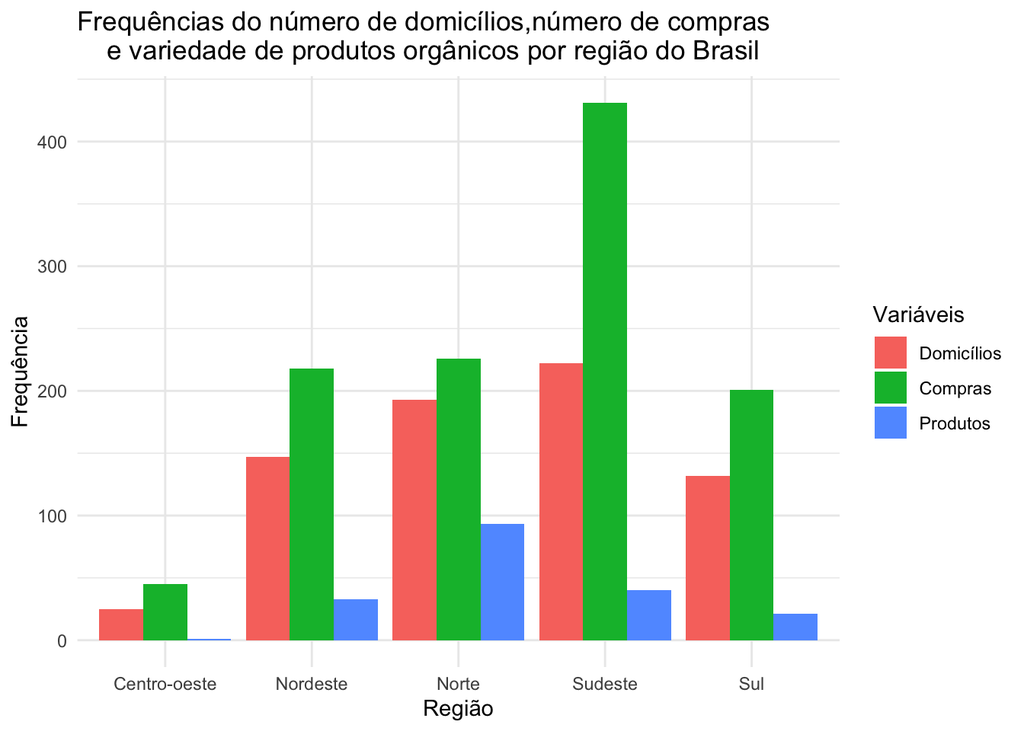

```r
TAB_6_PESQ_M <- as.data.table(TAB_6_PESQ[(1:(nrow(TAB_6_PESQ)-1))
                                         ,c("Região"
                                         ,"Frequência - Domicílios"
                                         ,"Frequência - Compras"
                                         ,"Frequência - Produtos")])
colnames(TAB_6_PESQ_M)<-c("Região"
                          ,"Domicílios"
                          ,"Compras"
                          ,"Produtos")


TAB_6_PESQ_M <- melt(TAB_6_PESQ_M,id.vars = 1)



ggplot(TAB_6_PESQ_M,aes(x = Região,y = value)) +
  geom_bar(aes(fill = variable),stat = "identity",position = "dodge")+
  labs(
    title = "Frequências do número de domicílios,número de compras
    e variedade de produtos orgânicos por região do Brasil"
    ,y = "Frequência"
    ,fill = "Variáveis")+
  theme_minimal()
```

## TABELA 7 – Despesa média com alimentação e produtos orgânicos das famílias que consumiram e não consumiram produtos orgânicos

```r
DOM_ORG<-SBT_ORGANICOS[,c("COD_UPA","NUM_DOM")]
SBT_COD_DOM_ANALISE_FUNC<-function(data){
  dm<-dim(data)
  dm<-as.numeric(dm[1])
  sbt_prod_F<-as_tibble(NULL)
  sbt_prod_1<-as_tibble(NULL)
  for(i in 1:dm){
    sbt_prod_F<-filter(SBT_ANALISE,SBT_ANALISE[,4]==as.numeric(data[i,1])& SBT_ANALISE[,5]==as.numeric(data[i,2]))
    sbt_prod_1<-rbind(sbt_prod_1,sbt_prod_F)
  }
  return(sbt_prod_1)
}
SBT_DOM_ORG<-SBT_COD_DOM_ANALISE_FUNC(DOM_ORG)

TAB_7_DESP_PESQ_1<-SBT_ANALISE%>%
  summarise(n=sum(valor_mensal))%>%
  mutate(n=n/SOMA_TOTAL_PESOS)

TAB_7_DESP_PESQ_2<-SBT_DOM_ORG%>%
  group_by(COD_UPA,NUM_DOM)%>%
  summarise(m=sum(valor_mensal/PESO_FINAL),.groups="keep")

TAB_7_DESP_PESQ_3<-SBT_ORGANICOS%>%
  group_by(COD_UPA,NUM_DOM)%>%
  summarise(m=sum(valor_mensal/PESO_FINAL),.groups="keep")

TAB_7_DESP_PESQ_T1<-as.data.frame(rbind(mean(TAB_7_DESP_PESQ_3$m),0))
TAB_7_DESP_PESQ_T2<-rbind(mean(TAB_7_DESP_PESQ_2$m),TAB_7_DESP_PESQ_1)

TAB_7_DESP_PESQ<-cbind(TAB_7_DESP_PESQ_T1,TAB_7_DESP_PESQ_T2)%>%
  mutate("Produtos orgânicos"=V1,"Alimentação"=n,.keep="none")%>%
  mutate("Famílias"=c("Consumiram","Não Consumiram"),.before=1)

formattable(TAB_7_DESP_PESQ,align = c("l",rep("r",NCOL(TAB_7_DESP_PESQ))))
```

| Famílias | Produtos orgânicos | Alimentação |
| --- | --- | --- |
| Consumiram | 51.08319 | 2234.2507 |
| Não Consumiram | 0.00000 | 658.2306 |